# Class 4 Lecture Demo

’Spring 2023

### Class 4 Lecture Demo - Thematic Mapping, Part II

[Class 4 Section Agenda](https://gis-nspe-tns.github.io/GIS_NINT5380_sp23/agendas/c4_agenda_spring_23_NINT5380.html)

[Class 3 Assignment Submissions](https://weekly-submissions.s3.amazonaws.com/c3_sp23_submissions.pdf)

[Class 4 Lab Demonstration Data](https://www.dropbox.com/s/vqst2u1cfwhxboj/ACS_2020_5YR_COUNTY.gdb.zip?dl=1)

- **Thematic Mapping Part II**
  - [Choropleth Definition](https://en.wikipedia.org/wiki/Choropleth_map):

> A choropleth map (from Greek χῶρος “area/region” and πλῆθος “multitude”) is a type of thematic map in which areas are shaded or patterned in proportion to a statistical variable that represents an aggregate summary of a geographic characteristic within each area, such as population density or per-capita income.

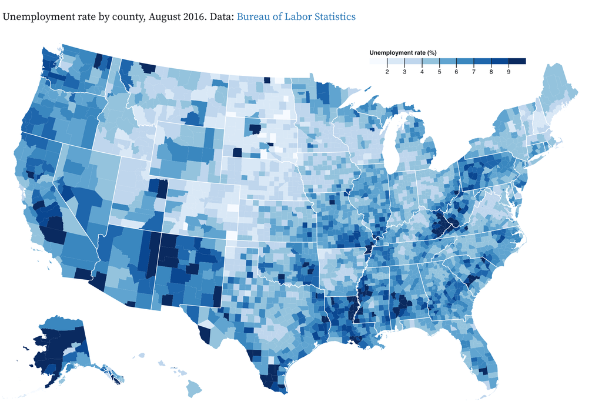

*Choropleth Example*

*source: https://observablehq.com/@d3/choropleth*

- [Census Geographies - Hierarchy](https://www.census.gov/content/dam/Census/data/developers/geoareaconcepts.pdf)

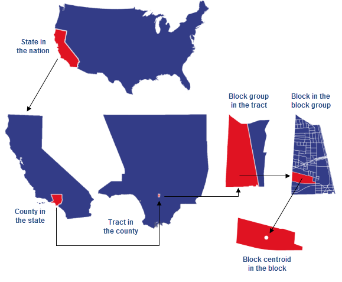

*U.S. Census Geographies*

*source: https://learn.arcgis.com/en/related-concepts/united-states-census-geography.htm*

- [Gerrymandering Definition](https://en.wikipedia.org/wiki/Gerrymandering)

> Gerrymandering is a practice intended to establish an unfair political advantage for a particular party or group by manipulating district boundaries, which is most commonly used in first-past-the-post electoral systems.

[figure not shown]

*source: Elkanah Tisdale (1771-1835) (often falsely attributed to Gilbert Stuart)[1] - Originally published in the Boston Centinel, 1812.*

- [MAUP](http://gispopsci.org/maup/)

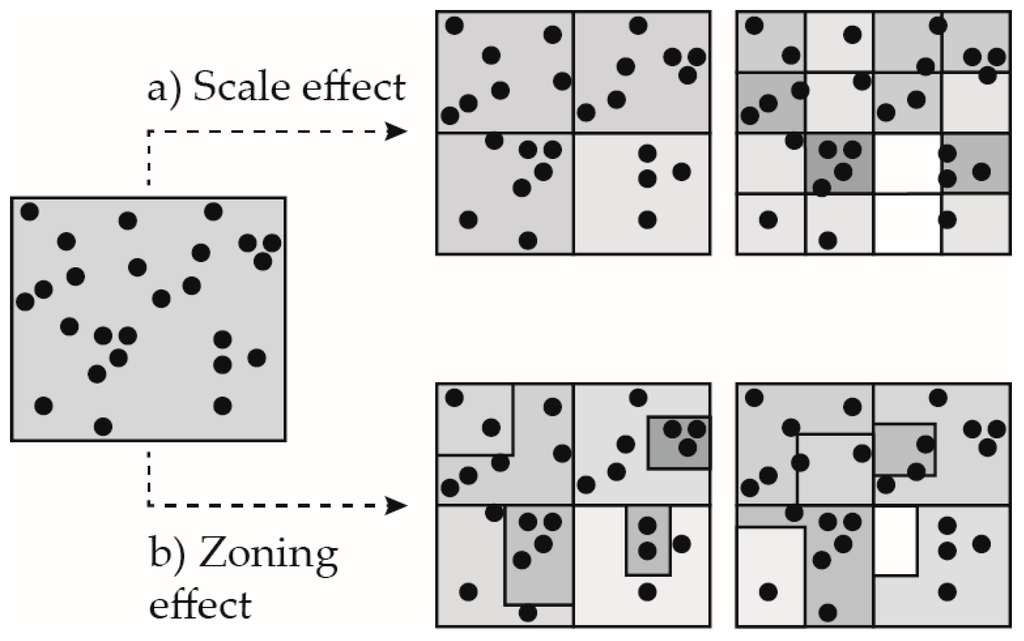

*source: https://www.mdpi.com/2313-576X/2/3/17/htm*

- Histogram

> A histogram is an approximate representation of the distribution of numerical data. It was first introduced by Karl Pearson.[1] To construct a histogram, the first step is to “bin” (or “bucket”) the range of values—that is, divide the entire range of values into a series of intervals—and then count how many values fall into each interval.

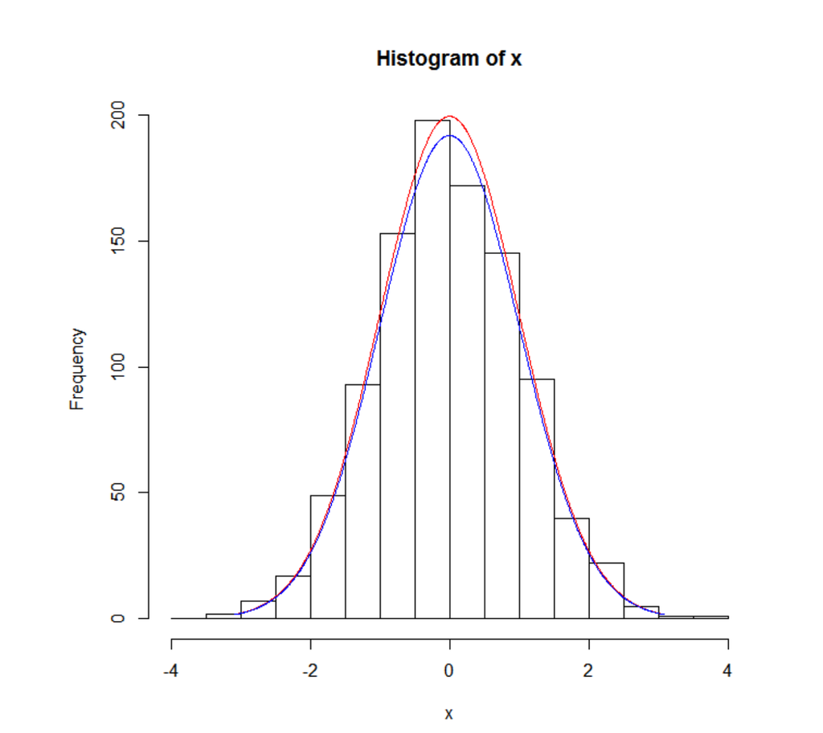

*source: https://stackoverflow.com/questions/14482502/histogram-with-curve-in-r*

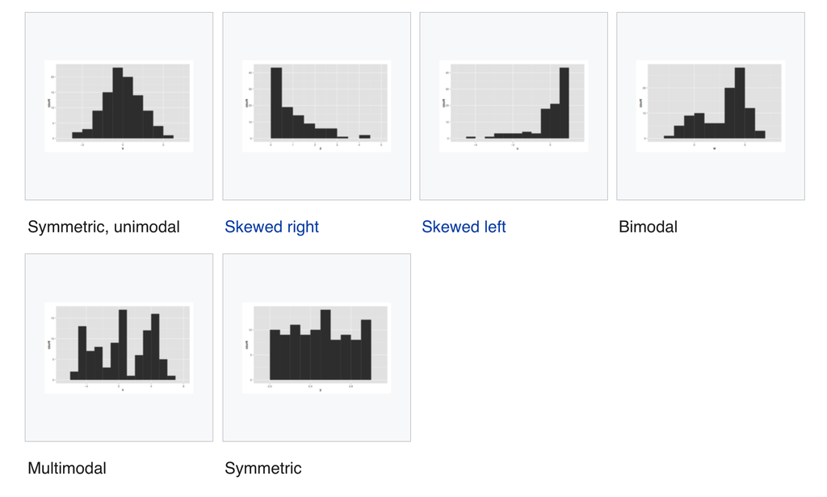

*source: https://en.wikipedia.org/wiki/Histogram*

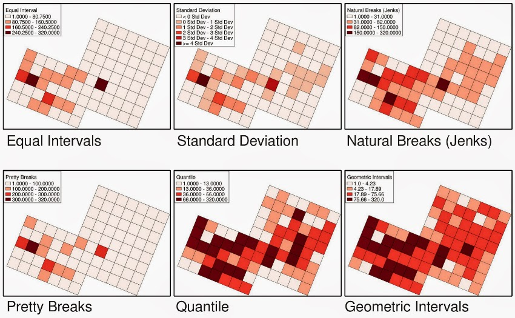

*Classification Methods*

*source:http://arc-team-open-research.blogspot.com/2014/07/geometric-classification-method-in-qgis.html*

- **EQUAL INTERVAL** divides the data into equal size classes (e.g., 0-10, 10-20, 20-30, etc.) and works best on data that is generally spread across the entire range. **Not suited for skewed data.**
- **QUANTILES** will create attractive maps that place an equal number of observations in each class: If you have 30 counties and 6 data classes, you’ll have 5 counties in each class. **The problem with quantiles is that you can end up with classes that have very different numerical ranges (e.g., 1-4, 4-9, 9-250…the last class is huge).**

> tip: Quantile expanded to 10 class breaks = Deciles, i.e. percentages %.
- **NATURAL BREAKS** is a kind of **“optimal” classification scheme** that finds class breaks that (for a given number of classes) will minimize within-class variance and maximize between-class differences.
- **MANUAL** There are many times we need to **manually set** one or all of the class breaks.
- **GEOMETRIC INTERVALS** can handle highly skewed data ofter better than other methods. Geometric interval works best when the data is spread over a large area and is not well distributed.
- [Classification, Breaks and Color](https://academy.datawrapper.de/article/117-color-palette-for-your-map)

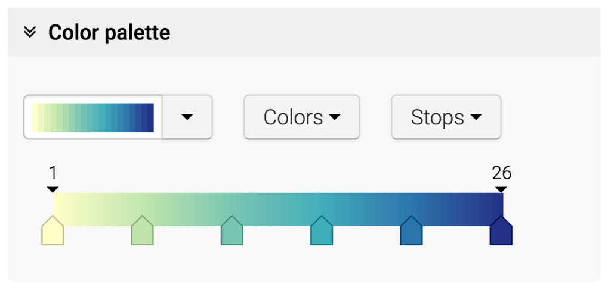

*Color for Choropleths*

*source: https://academy.datawrapper.de/article/117-color-palette-for-your-map*

#### Class 4 QGIS demonstrations:

- [US Census TIGER `.gdb`](https://www.census.gov/geographies/mapping-files/time-series/geo/tiger-data.2020.html#list-tab-8D0FFIBS8PJO7C8Z1I)
- [Class 4 Lab Demonstration Data](https://www.dropbox.com/s/vqst2u1cfwhxboj/ACS_2020_5YR_COUNTY.gdb.zip?dl=1)
- `.gdb` structure
- Data Normalization
  - [US Census ‘land area’ definition](https://www.census.gov/quickfacts/fact/note/US/POP060210)
  - `B01001_001E - Total Population`
  - `B01001_002E - Male Population`
  - `B01001_026E- Female Population`
  - [Census variable api 2020](https://api.census.gov/data/2020/acs/acs5/variables.html)
- Classification Demo
  - Join Column = `GEOID_Data` (geometry) + `GEOID` (tabular)
- Classification Method Symbolization

#### Class 4 Links:

- [Assignment](https://gis-nspe-tns.github.io/GIS_NINT5380_sp23/assignments/c4_assignment_spring_23_NINT5380.html)
- [Lab Supplemental](https://gis-nspe-tns.github.io/GIS_NINT5380_sp23/labs/c4.lab.html)
- [Class 4 Agenda](https://gis-nspe-tns.github.io/GIS_NINT5380_sp23/agendas/c4_agenda_spring_23_NINT5380.html)
- [Class 4 Demonstration Lab](https://gis-nspe-tns.github.io/GIS_NINT5380_sp23/demos/c4.lecture.demo.html)